# meth02_analyze_data.R

ImageBuilderAdmin

Sun Jun 24 12:06:04 2018

# Analyze methylation data

Using data preprocessed in our script:  
meth01_process_data.R

Local library

```r
.libPaths("C:/EBC3/Rpackages")
knitr::opts_knit$set(root.dir = "../")
```

```r
#if(!exists("WB.noob")){
#  source("code/meth01_process_data.R")
#}

# load the data
library(minfi)
```

```
## locfit 1.5-9.1    2013-03-22
```

```
## Setting options('download.file.method.GEOquery'='auto')
```

```
## Setting options('GEOquery.inmemory.gpl'=FALSE)
```

```r
load("C:/EBC3/Data/WB.noob.RData") # phenotype data
dim(WB.noob)
```

```
## [1] 864678     20
```

```r
cellprop<-read.csv("C:/EBC3/methylation-lab/data/cellprop_WB_20samps_EPICdemo.csv") # cell type composition
load("C:/EBC3/Data/betas.rcp.RData") # processed betas
load("C:/EBC3/Data/Gbeta.RData") # annotation file
```

load packages

```r
suppressPackageStartupMessages({
  library(CpGassoc) # for running association analysis between methylation levels values and phenotype of interest
  library(data.table) # for fast aggregation of large data
  library(qqman) # for visualization of data
  library(IlluminaHumanMethylationEPICanno.ilm10b2.hg19) # for annotation for Illumina's EPIC methylation arrays
  library(DMRcate) # for regional analysis
  library(MASS) # for basic statistics
  library(sandwich) # for linear regression (robust sandwich variance estimator)
  library(lmtest) # for testing Linear Regression Models
  library(stringi) # string manipulation
})
```

consolidate our phenodata

```r
pheno = data.frame(pData(WB.noob))
pheno = pheno[,c("SMOKE_STATUS","SEX","AGE","Array")]
pheno = cbind(pheno,cellprop)

pheno$SMOKE_STATUS = factor(pheno$SMOKE_STATUS)
pheno$SEX          = factor(pheno$SEX)

# cleanup
rm(WB.noob)
```

quick check of the distribution of smoke between arrays

```r
table(pheno[,c("SMOKE_STATUS","Array")])
```

```
##             Array
## SMOKE_STATUS R01C01 R02C01 R03C01 R04C01 R05C01 R06C01 R07C01 R08C01
##   NON-SMOKER      1      1      2      2      2      0      1      1
##   SMOKER          1      2      1      0      2      2      1      1
```

```r
## Cleaning up the methylation data
```

Filters a matrix of beta values by distance to single nucleotide polymorphism (SNP) and SNPs with the minor allele frequency (MAF) of 5% (rare variant). Also removes crosshybridising probes and sex-chromosome probes.

```r
dim(betas.rcp)
```

```
## [1] 864678     20
```

```r
betas.clean = rmSNPandCH(betas.rcp,  mafcut = 0.05, and = TRUE, rmcrosshyb = TRUE, rmXY= TRUE)
nCpG = dim(betas.clean)[1]
nCpG
```

```
## [1] 795440
```

# Running an Epigenome Wide Association

Here we run an EWAS on Smoking status (as a predictor of methylation)  
First we can run a linear regression on a single CpG that we have already picked

```r
CpG.name = "cg05575921"
CpG.level <- betas.clean[CpG.name,]
```

difference in methylation between smokers and non-smokers for this CpG some descriptive statistics

```r
knitr::kable(cbind(Min   = round( tapply(CpG.level,pheno$SMOKE_STATUS,min   ),3),
                   Mean  = round( tapply(CpG.level,pheno$SMOKE_STATUS,mean  ),3),
                   Median= round( tapply(CpG.level,pheno$SMOKE_STATUS,median),3),
                   Max   = round( tapply(CpG.level,pheno$SMOKE_STATUS,max   ),3),
                   SD    = round( tapply(CpG.level,pheno$SMOKE_STATUS,sd    ),3),
                   N     = table( pheno$SMOKE_STATUS )))
```

|  | Min | Mean | Median | Max | SD | N |
| --- | --- | --- | --- | --- | --- | --- |
| NON-SMOKER | 0.807 | 0.880 | 0.893 | 0.929 | 0.041 | 10 |
| SMOKER | 0.619 | 0.694 | 0.664 | 0.831 | 0.072 | 10 |

difference in beta methylation values between Smokers and non smokers

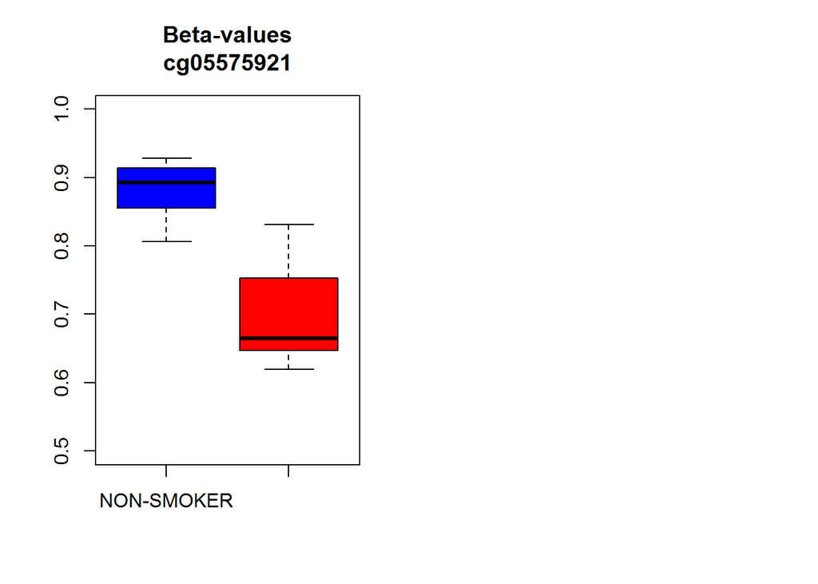

```r
par(mfrow=c(1,2))
boxplot(CpG.level ~ pheno$SMOKE_STATUS, main=paste0("Beta-values\n", CpG.name), col=c("blue","red"),ylim=c(.5,1))
```

linear regression on betas

```r
summary(lm(CpG.level~pheno$SMOKE_STATUS))$coefficients[2,c("Estimate", "Pr(>|t|)","Std. Error")]
```

```
##      Estimate      Pr(>|t|)    Std. Error
## -1.857140e-01  1.264168e-06  2.612711e-02
```

what if we use raw beta?

```r
CpG.level.raw <- minfi::getBeta(WB)[CpG.name,] # select the same CpG
```

descriptive stats are different

```r
knitr::kable(cbind(Min    = round( tapply(CpG.level.raw, pheno$SMOKE_STATUS,min   ),3),
                   Mean   = round( tapply(CpG.level.raw, pheno$SMOKE_STATUS,mean  ),3),
                   Median = round( tapply(CpG.level.raw, pheno$SMOKE_STATUS,median),3),
                   Max    = round( tapply(CpG.level.raw, pheno$SMOKE_STATUS,max   ),3),
                   SD     = round( tapply(CpG.level.raw, pheno$SMOKE_STATUS,sd    ),3),
                   N      = table( pheno$SMOKE_STATUS )))
```

|  | Min | Mean | Median | Max | SD | N |
| --- | --- | --- | --- | --- | --- | --- |
| NON-SMOKER | 0.773 | 0.868 | 0.878 | 0.909 | 0.040 | 10 |
| SMOKER | 0.511 | 0.639 | 0.598 | 0.762 | 0.086 | 10 |

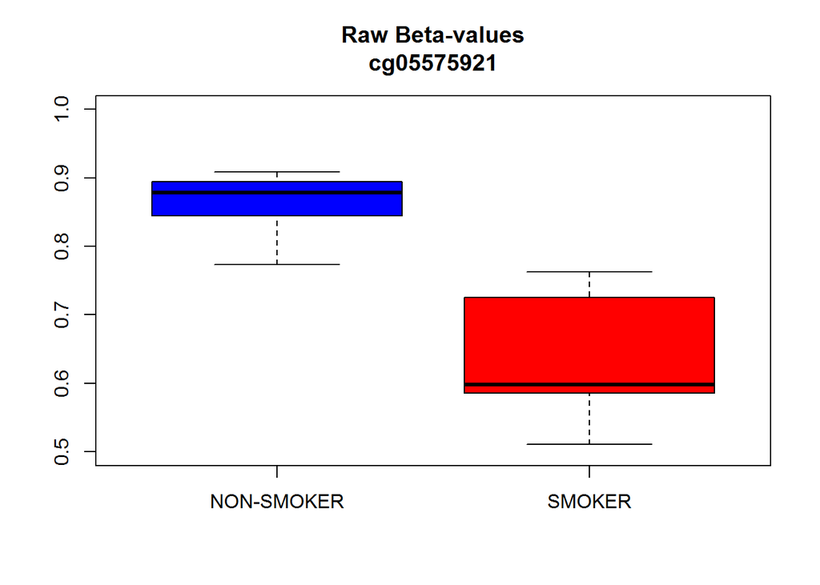

```r
boxplot(CpG.level.raw ~ pheno$SMOKE_STATUS, main=paste0("Raw Beta-values\n",CpG.name), col=c("blue","red"),ylim=c(.5,1))
```

linear regression on raw betas

```r
summary(lm(CpG.level.raw ~ pheno$SMOKE_STATUS))$coefficients[2,c("Estimate", "Pr(>|t|)","Std. Error")] # results are different
```

```
##      Estimate      Pr(>|t|)    Std. Error
## -2.288721e-01  4.783444e-07  2.999866e-02
```

comparison with m-values

```r
CpG.mlevel = log2(CpG.level/(1-CpG.level))

knitr::kable(cbind(Min    = round( tapply(CpG.mlevel, pheno$SMOKE_STATUS,min   ),3),
                   Mean   = round( tapply(CpG.mlevel, pheno$SMOKE_STATUS,mean  ),3),
                   Median = round( tapply(CpG.mlevel, pheno$SMOKE_STATUS,median),3),
                   Max    = round( tapply(CpG.mlevel, pheno$SMOKE_STATUS,max   ),3),
                   SD     = round( tapply(CpG.mlevel, pheno$SMOKE_STATUS,sd    ),3),
                   N      = table(pheno$SMOKE_STATUS)))
```

|  | Min | Mean | Median | Max | SD | N |
| --- | --- | --- | --- | --- | --- | --- |
| NON-SMOKER | 2.061 | 2.944 | 3.065 | 3.703 | 0.545 | 10 |
| SMOKER | 0.703 | 1.218 | 0.986 | 2.299 | 0.527 | 10 |

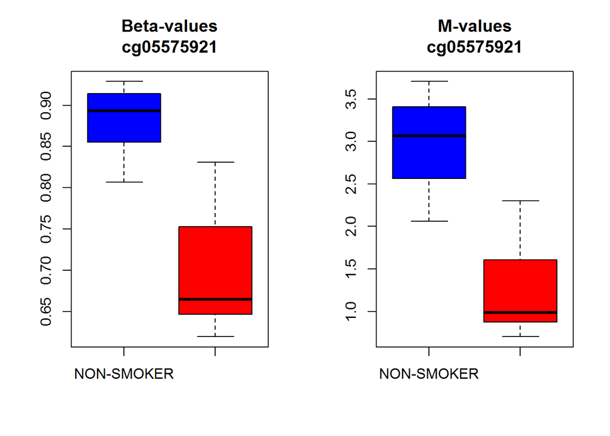

```r
par(mfrow=c(1,2))
boxplot(CpG.level  ~ pheno$SMOKE_STATUS, main=paste0("Beta-values\n",CpG.name), col=c("blue","red"))
boxplot(CpG.mlevel ~ pheno$SMOKE_STATUS, main=paste0("M-values\n"   ,CpG.name), col=c("blue","red"))
```

linear regression on m-values

```r
summary(lm(CpG.mlevel~pheno$SMOKE_STATUS))$coefficients[2,c("Estimate", "Pr(>|t|)","Std. Error")]
```

```
##      Estimate      Pr(>|t|)    Std. Error
## -1.726253e+00  1.052368e-06  2.395919e-01
```

we can always extract measures of the relative quality of statistical models - e.g. adjusted R2 - to look at model performance  
model on betas

```r
summary(lm(CpG.level~pheno$SMOKE_STATUS))$adj.r.squared
```

```
## [1] 0.7227292
```

model on mvalues

```r
summary(lm(CpG.mlevel~pheno$SMOKE_STATUS))$adj.r.squared
```

```
## [1] 0.7282283
```

## EWAS and results using CpGassoc

see [Barfield et al. Bioinformatics 2012](http://www.ncbi.nlm.nih.gov/pubmed/22451269)  
Smoking as predictor  
note that CpGassoc is quite fast for running almost a million regressions!

```r
pheno$SMOKE = ifelse(pheno$SMOKE_STATUS=="SMOKER",1,0)
system.time(results1 <- cpg.assoc(betas.clean, pheno$SMOKE))
```

```
##    user  system elapsed
##   20.65    0.61   21.30
```

there are several components of the results

```r
class(results1)
```

```
## [1] "cpg"
```

```r
names(results1)
```

```
## [1] "results"      "Holm.sig"     "FDR.sig"      "info"
## [5] "indep"        "covariates"   "chip"         "coefficients"
```

look at a few results  
here effect size is ~ mean difference in methylation proportion

```r
head(cbind(results1$coefficients[,4:5], P.value=results1$results[,3]))
```

```
##              effect.size    std.error   P.value
## cg18478105  5.132834e-04 0.0005098265 0.3273835
## cg14361672 -7.272109e-03 0.0043034528 0.1083051
## cg01763666  5.246844e-03 0.0089740860 0.5660293
## cg12950382 -2.180899e-05 0.0095405381 0.9982012
## cg02115394 -4.930763e-03 0.0042298752 0.2589509
## cg13417420 -4.826353e-03 0.0095144186 0.6181258
```

and the top hits

```r
head(cbind(results1$coefficients[,4:5], P.value=results1$results[,3])[order(results1$results[,3]),])
```

```
##             effect.size   std.error      P.value
## cg24083923 -0.003231850 0.000403159 2.380605e-07
## cg14585907  0.011928312 0.001516494 3.116224e-07
## cg03833046 -0.009010161 0.001210091 6.707178e-07
## cg26703534 -0.059387198 0.008225023 1.022378e-06
## cg05575921 -0.185714037 0.026127106 1.264168e-06
## cg23325932 -0.007654188 0.001100445 1.691766e-06
```

check with previous result on our selected CpG (running lm without CpGassoc)

```r
cbind(results1$coefficients[,4:5],results1$results[,c(1,3)])[CpG.name,]
```

```
##            effect.size  std.error CPG.Labels      P.value
## cg05575921   -0.185714 0.02612711 cg05575921 1.264168e-06
```

```r
summary(lm(CpG.level~pheno$SMOKE_STATUS))
```

```
##
## Call:
## lm(formula = CpG.level ~ pheno$SMOKE_STATUS)
##
## Residuals:
##       Min        1Q    Median        3Q       Max
## -0.074744 -0.046218 -0.001026  0.034077  0.136916
##
## Coefficients:
##                          Estimate Std. Error t value Pr(>|t|)
## (Intercept)               0.87992    0.01847  47.628  < 2e-16 ***
## pheno$SMOKE_STATUSSMOKER -0.18571    0.02613  -7.108 1.26e-06 ***
## ---
## Signif. codes:  0 '***' 0.001 '**' 0.01 '*' 0.05 '.' 0.1 ' ' 1
##
## Residual standard error: 0.05842 on 18 degrees of freedom
## Multiple R-squared:  0.7373, Adjusted R-squared:  0.7227
## F-statistic: 50.53 on 1 and 18 DF,  p-value: 1.264e-06
```

Bonferroni significant hits

```r
table(results1$results[,3] < 0.05/(nCpG))
```

```
##
##  FALSE
## 795440
```

FDR significant hits

```r
table(results1$results[,5] < 0.05)
```

```
##
##  FALSE
## 795440
```

EWAS with adjustment for cell types now we can run the linear regression on betas adjusting for cell proportions Need sex as indicator in covariate matrix

```r
results2 = cpg.assoc(
           betas.clean
          ,pheno$SMOKE
          ,covariates=pheno[,c("SEX","AGE","CD8T","CD4T","NK","Bcell","Mono","Gran")]
          )

print(results2)
```

```
##
## The top ten CpG sites were:
##        CPG.Labels T.statistic      P.value Holm.sig       FDR   gc.p.value
## 630202 cg14825383   11.127717 5.920770e-07    FALSE 0.4709617 2.281131e-06
## 199576 cg24709019   -9.426059 2.725003e-06    FALSE 0.8005753 1.008579e-05
## 696080 cg18833170    8.655550 5.869090e-06    FALSE 0.8005753 2.118566e-05
## 747093 cg02336621    8.608253 6.162860e-06    FALSE 0.8005753 2.220785e-05
## 249775 cg07843905    8.412990 7.556628e-06    FALSE 0.8005753 2.703078e-05
## 341452 cg24749455   -8.231414 9.164483e-06    FALSE 0.8005753 3.254633e-05
## 19094  cg05575921   -8.074420 1.085664e-05    FALSE 0.8005753 3.830359e-05
## 696125 cg21931972   -7.788026 1.488576e-05    FALSE 0.8005753 5.185119e-05
## 414427 cg02694972   -7.785439 1.492884e-05    FALSE 0.8005753 5.199499e-05
## 779257 cg15130102    7.739949 1.570903e-05    FALSE 0.8005753 5.459545e-05
##
## To access results for all  795440  CpG sites use object$results
## or sort(object)$results to obtain results sorted by p-value.
##
## General info:
##   Min.P.Observed Num.Cov fdr.cutoff FDR.method Phenotype chipinfo num.Holm
## 1    5.92077e-07       8       0.05         BH     SMOKE     NULL        0
##   num.fdr
## 1       0
##
## 0 sites were found significant by the Holm method
## 0 sites were found significant by BH method
##
## The beta values were taken from: betas.clean
## Effect sizes and standard error can be accessed using $coefficients
## Other attributes are: results, Holm.sig, FDR.sig, info, indep, covariates, chip
##  They can be accessed using the $
```

using mvalues

```r
results3 <- cpg.assoc(
           betas.clean
          ,pheno$SMOKE
          ,covariates=pheno[,c("SEX","AGE","CD8T","CD4T","NK","Bcell","Mono","Gran")]
          ,logit.transform=TRUE
          )

print(results3)
```

```
##
## The top ten CpG sites were:
##        CPG.Labels T.statistic      P.value Holm.sig       FDR   gc.p.value
## 630202 cg14825383   11.486759 4.401959e-07    FALSE 0.3501494 1.849329e-06
## 199576 cg24709019   -9.099249 3.749068e-06    FALSE 0.7722102 1.482670e-05
## 696080 cg18833170    8.864787 4.740407e-06    FALSE 0.7722102 1.859332e-05
## 747093 cg02336621    8.759589 5.275105e-06    FALSE 0.7722102 2.061049e-05
## 696125 cg21931972   -8.080736 1.078237e-05    FALSE 0.7722102 4.096308e-05
## 249775 cg07843905    8.019506 1.152636e-05    FALSE 0.7722102 4.366652e-05
## 341452 cg24749455   -7.945875 1.249572e-05    FALSE 0.7722102 4.717569e-05
## 779257 cg15130102    7.724677 1.598079e-05    FALSE 0.7722102 5.968238e-05
## 474550 cg04476877    7.719571 1.607279e-05    FALSE 0.7722102 6.001042e-05
## 660422 cg22253596   -7.692543 1.656942e-05    FALSE 0.7722102 6.177950e-05
##
## To access results for all  795440  CpG sites use object$results
## or sort(object)$results to obtain results sorted by p-value.
##
## General info:
##   Min.P.Observed Num.Cov fdr.cutoff FDR.method Phenotype chipinfo num.Holm
## 1   4.401959e-07       8       0.05         BH     SMOKE     NULL        0
##   num.fdr
## 1       0
##
## 0 sites were found significant by the Holm method
## 0 sites were found significant by BH method
##
## The beta values were taken from: betas.clean
## Effect sizes and standard error can be accessed using $coefficients
## Other attributes are: results, Holm.sig, FDR.sig, info, indep, covariates, chip
##  They can be accessed using the $
```

## Genomic inflation in EWAS

qqplot and lambda interpretation

```r
par(mfrow=c(1,1))
plot(results1, main="QQ plot for association between methylation and Smoking\nadjusted for cell proportions")
```

[figure not shown]

```r
plot(results2, main="QQ plot for association between (mvals) methylation and Smoking\nadjusted for cell proportions")
```

[figure not shown]

Lambda - this is a summary measure of genomic inflation  
ratio of observed vs expected median p-value - is there early departure of the qqline estimated at -log10(median=0.5) ~ 0.3 on the x-axis of a qqplot

```r
lambda <- function(p) median(qchisq(p, df=1, lower.tail=FALSE), na.rm=TRUE) / qchisq(0.5, df=1)
```

Lambda before cell type adjustment

```r
lambda(results1$results[,3])
```

```
## [1] 1.301815
```

Lambda after cell type adjustment

```r
lambda(results2$results[,3])
```

```
## [1] 1.237874
```

Map the results to the epigenetic annotation

```r
IlluminaAnnot<-as.data.frame(getAnnotation(Gbeta))
```

Restrict to good quality probes and order data frames

```r
IlluminaAnnot <- IlluminaAnnot[IlluminaAnnot$Name %in% results2$results$CPG.Labels,]
IlluminaAnnot <- IlluminaAnnot[match(results2$results$CPG.Labels, IlluminaAnnot$Name),]
```

Check that CpGs are align

```r
identical(IlluminaAnnot$Name,results2$results$CPG.Labels)
```

```
## [1] TRUE
```

```r
datamanhat <- data.frame(CpG=results2$results[,1],Chr=as.character(IlluminaAnnot$chr),
                         Mapinfo=IlluminaAnnot$pos, UCSC_RefGene_Name=IlluminaAnnot$UCSC_RefGene_Name,
                         Pval=results2$results[,3], Eff.Size = results2$coefficients[,4], Std.Error = results2$coefficients[,5])
```

see where the top hits are

```r
head(datamanhat[order(datamanhat$Pval), ],n=7)
```

```
##               CpG   Chr   Mapinfo UCSC_RefGene_Name         Pval
## 630202 cg14825383 chr15  91768936         SV2B;SV2B 5.920770e-07
## 199576 cg24709019 chr14  74846980                   2.725003e-06
## 696080 cg18833170 chr16  24788505            TNRC6A 5.869090e-06
## 747093 cg02336621 chr22  19111998                   6.162860e-06
## 249775 cg07843905  chr7  38376378                   7.556628e-06
## 341452 cg24749455 chr12 109938373       UBE3B;UBE3B 9.164483e-06
## 19094  cg05575921  chr5    373378              AHRR 1.085664e-05
##            Eff.Size    Std.Error
## 630202  0.014902792 0.0013392497
## 199576 -0.018075324 0.0019175907
## 696080  0.003928523 0.0004538733
## 747093  0.007103310 0.0008251744
## 249775  0.032945581 0.0039160371
## 341452 -0.010442367 0.0012685993
## 19094  -0.191972511 0.0237753923
```

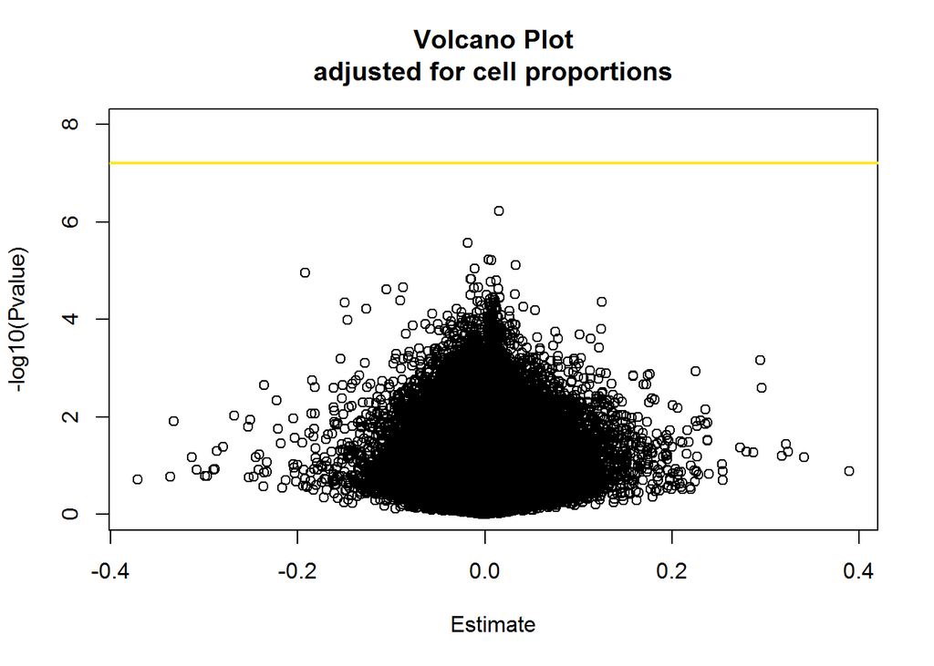

```r
plot(results2$coefficients[,4],-log10(results2$results[,3]),
     xlab="Estimate", ylab="-log10(Pvalue)", main="Volcano Plot\nadjusted for cell proportions",ylim=c(0,8))
#Bonferroni threshold & FDR threshold
abline(h = -log10(0.05/(nCpG)), lty=1, col="#FDE725FF", lwd=2)
```

## Manhattan plot for cell-type adjusted EWAS

Reformat the variable Chr (so we can simplify and use a numeric x-axis)

```r
datamanhat$Chr <- as.numeric(sub("chr","",datamanhat$Chr))
```

the function manhattan needs data.frame including CpG, Chr, MapInfo and Pvalues

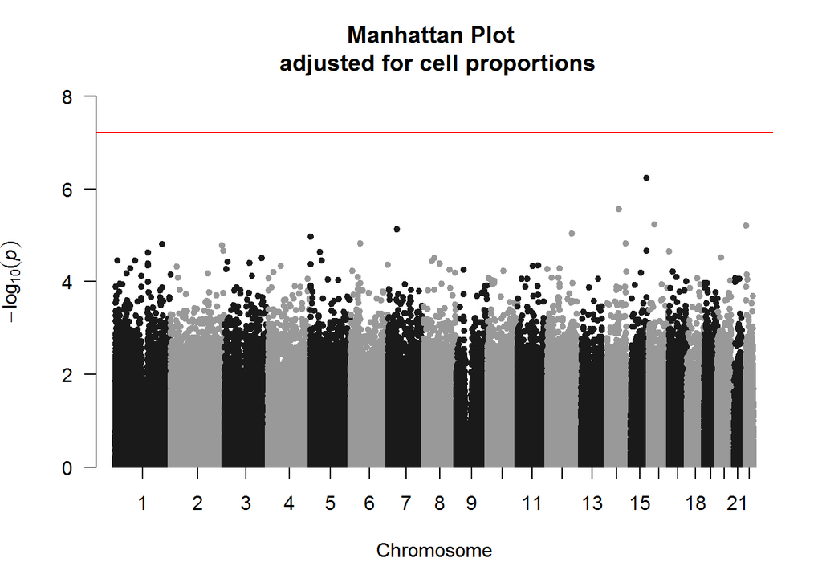

```r
manhattan(datamanhat,"Chr","Mapinfo", "Pval", "CpG",
          genomewideline = -log10(0.05/(nCpG)), suggestiveline = FALSE,
          main = "Manhattan Plot \n adjusted for cell proportions",ylim=c(0,8))
```

cleanup

```r
rm(nCpG, CpG.name, CpG.level, CpG.mlevel, datamanhat, IlluminaAnnot,lambda,results1,results2,results3,Gbeta,WB,betas.rcp,CpG.level.raw);gc()
```

```
##             used   (Mb) gc trigger   (Mb)  max used   (Mb)
## Ncells  15913984  849.9   39955785 2133.9  22899590 1223.0
## Vcells 137811964 1051.5  454212272 3465.4 454137176 3464.8
```

End of script 02